## 0.1 load data

```r
sample_info <- read.csv("Sample info.csv", stringsAsFactors = F) %>%
  filter(!grepl("ESC", description))%>%
  mutate(description = gsub("transfected MEF cultured in", "", description))

data_filtered <- read.delim("FinalReport_ori.txt", skip=8, header=T, sep = "\t", comment.char = "", fill = TRUE, stringsAsFactors = F) %>%
  select(PROBE_ID, contains("AVG_Signal"), contains("Detection.Pval"), -contains("8491191070_F"), -contains("8491191070_G"))

# gene_symbol_new <- read.delim("official_gene_names_non_alt_loci_set.txt", stringsAsFactors = F) %>%
#   select(symbol, prev_symbol, alias_symbol) %>%
#   filter(prev_symbol != "" | alias_symbol != "") %>%
#   separate(col = prev_symbol, into = paste0("new", 1:20), sep = "\\|") %>%
#   gather(key = gene_name, value = TargetID, - symbol) %>%
#   select(-gene_name, gene_name = symbol) %>%
#   filter(!is.na(TargetID)) %>%
#   arrange(gene_name)

# load ensembl genes

# ensembl_genes <- read.table("mm10_genes.gtf", sep = "\t") %>%
#   select(chr = V1, start = V4, end = V5, strand = V7, V9) %>%
#   separate(V9, into = paste0("new", 1:7), remove = T, sep = "; ") %>%
#   mutate(chr = paste0("chr", chr),
#          ensembl_id = gsub("gene_id ", "", new1),
#          gene_name = gsub("gene_name ", "", new3) %>% toupper()) %>%
#   select(chr, start, end, strand, ensembl_id, gene_name) %>%
#   makeGRangesFromDataFrame(keep.extra.columns = T)

# load ensembl to refseq translator

#
mart<- useMart("ensembl", dataset = "mmusculus_gene_ensembl")
# mart_data <- getBM(attributes=c("refseq_mrna_predicted", "refseq_mrna", "external_gene_name", "illumina_mouseref_8_v2"), filters = "illumina_mouseref_8_v2", values = data_filtered$PROBE_ID, mart=mart)
# saveRDS(mart_data, file = "mart_data.rds")

mart_data <- readRDS(file = "mart_data.rds")

predicted_refseq_to_real <- mart_data %>% filter(illumina_mouseref_8_v2 != "") %>%
  mutate(refseq_mrna = ifelse(refseq_mrna == "", refseq_mrna_predicted, refseq_mrna)) %>%
  filter(refseq_mrna != "", grepl("NM", refseq_mrna)) %>%
  select(-refseq_mrna_predicted) %>% unique() %>%
  group_by(illumina_mouseref_8_v2) %>% arrange(refseq_mrna) %>% do(head(., 1)) %>%
  ungroup()

refseq_to_genename <- read.table("refseq_to_genename.txt", stringsAsFactors = F)

gene_info <- read.delim("FinalReport_ori.txt", skip=8, header=T, sep = "\t", fill = TRUE, stringsAsFactors = F) %>%
  select(PROBE_ID, ACCESSION, SYMBOL) %>% tbl_df() %>%
  mutate(REFSEQ_ID = gsub("\\..*", "", ACCESSION)) %>%
  left_join(predicted_refseq_to_real, by = c("PROBE_ID" = "illumina_mouseref_8_v2")) %>%
  mutate(refseq = ifelse(!is.na(refseq_mrna), refseq_mrna, REFSEQ_ID)) %>%
  left_join(., refseq_to_genename, by = c("refseq" = "V1"), copy=TRUE) %>%
  mutate(gene_name = alias2SymbolTable(alias = SYMBOL, species = "Mm") %>% gsub("\\-.*", "", .),
         gene_name2 = alias2SymbolTable(alias = external_gene_name, species = "Mm"),
         gene_name = ifelse(is.na(gene_name), gene_name2, gene_name),
         gene_name = ifelse(is.na(gene_name), V2, gene_name),
         gene_name = ifelse(is.na(gene_name), SYMBOL, gene_name)) %>%
  select(-gene_name2, -contains("refseq_"), -SYMBOL, -ACCESSION, -external_gene_name, -V2) %>% unique()

background <- gene_info$gene_name %>% toupper() %>% unique()
universe <- length(background)
```

- remove genes that are only expressed in 1 or less sample

```r
genes_to_keep <- data_filtered %>%
  select(PROBE_ID, contains("Pval")) %>%
  gather(key = sample, value = pval, -PROBE_ID) %>%
  group_by(PROBE_ID) %>%
  summarize(samples_detected = sum(pval<0.05)) %>%
  filter(samples_detected >= 2)

data_filtered_expressed <- data_filtered %>%
  select(PROBE_ID, contains("Signal")) %>%
  setnames(colnames(.)[-1], as.character(sample_info$Sample))

probe_names <- data_filtered_expressed$PROBE_ID

data_filtered_matrix <- data_filtered_expressed %>%
  select(-PROBE_ID) %>%
  data.matrix()

rownames(data_filtered_matrix) <- probe_names

# data_filtered_matrix[x>0.01] <- median(data_filtered_matrix[x>0.01], na.rm = T)

data_filtered_matrix_expressed <- data_filtered_matrix %>%
  subset(rownames(.) %in% genes_to_keep$PROBE_ID)
```

## 0.2 Check distribution of gene expression

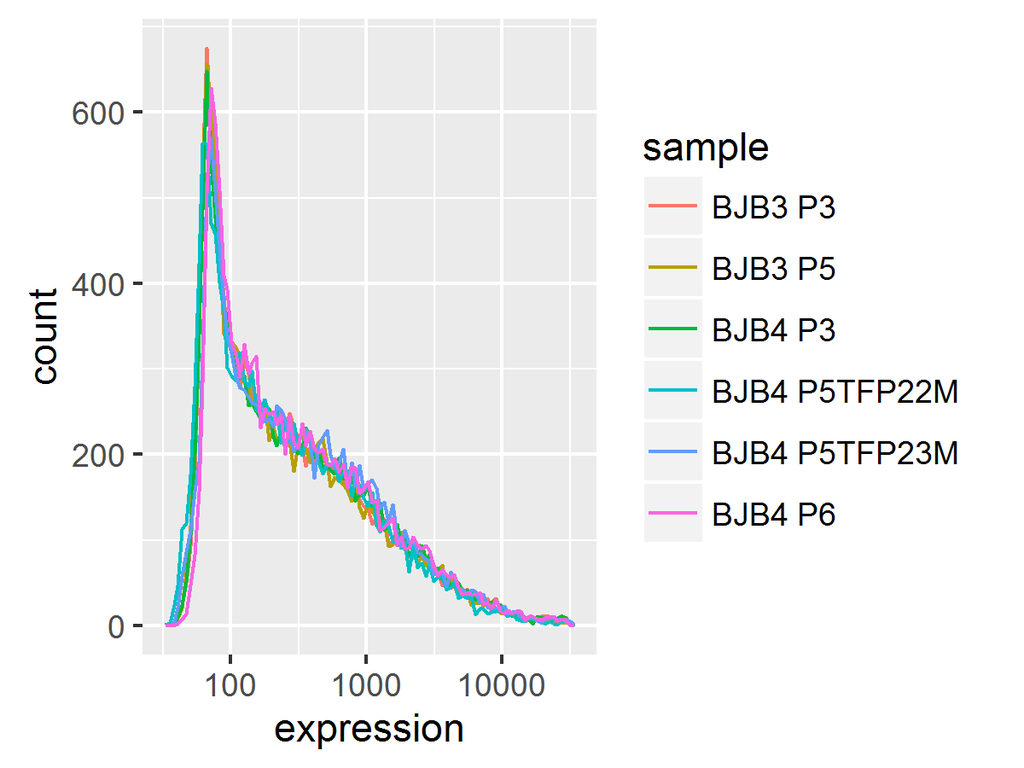

```r
data_filtered_matrix_expressed %>%
  as.data.frame() %>%
  # select(-contains("Pval")) %>%
  gather(key = sample, value = expression) %>%
  mutate(expression = as.numeric(expression)+1) %>%
  tbl_df() %>%
  ggplot(aes(expression, color = sample)) +
  geom_line(stat="bin", bins = 100) +
  scale_x_log10()
```

## 0.3 Quantile normalize

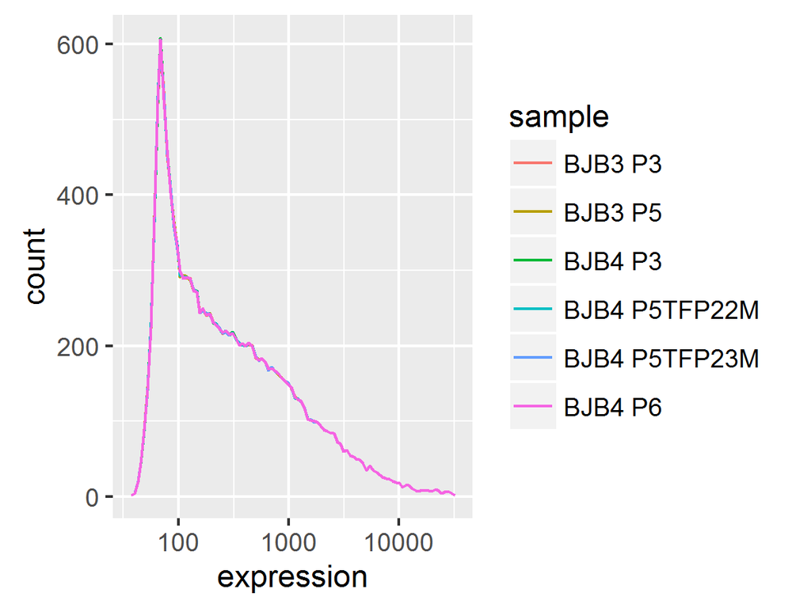

```r
data_filtered_matrix_expressed <- data_filtered_matrix_expressed %>%
  normalizeQuantiles()

data_filtered_matrix_expressed %>%
  as.data.frame() %>%
  # select(-contains("Pval")) %>%
  gather(key = sample, value = expression) %>%
  mutate(expression = as.numeric(expression)+1) %>%
  tbl_df() %>%
  ggplot(aes(expression, color = sample)) +
  geom_line(stat="bin", bins = 100) +
  scale_x_log10()
```

## 0.4 Check global correlations

- spearman correlation

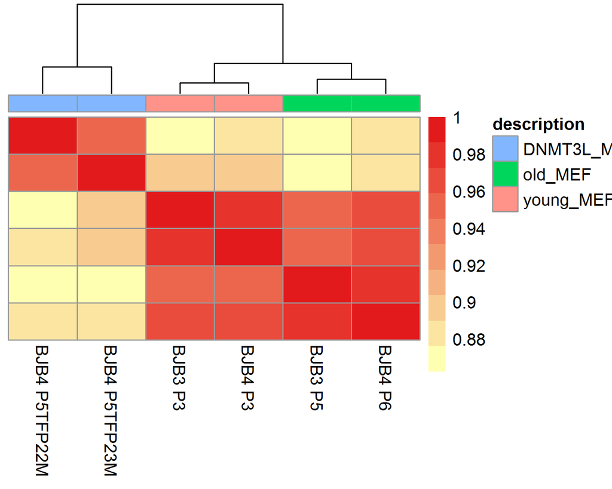

```r
labels <- sample_info %>% column_to_rownames("Sample") %>% select(-Chip_ID)

pallet <- brewer.pal(n=4, name="YlOrRd") %>% .[c(1,length(.))] %>% colorRampPalette(colors = .)

cor(data_filtered_matrix_expressed, method = "spearman") %>%
  pheatmap(color = pallet(10), annotation_col = labels, show_rownames = F, annotation_names_col = F, treeheight_row = 0, cluster_cols = hclust(dist(1-cor(data_filtered_matrix_expressed, method = "spearman"))))
```

- spearman correlation distance on log transformed expression

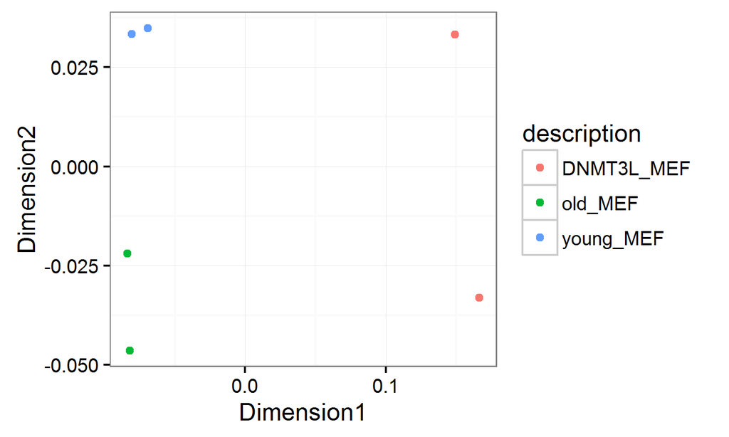

```r
dist(1-cor(log10(data_filtered_matrix_expressed+1), method = "spearman")) %>%
# log10(data_filtered_matrix_expressed+1) %>%  t %>% dist() %>%
  # MASS::isoMDS() %>% .$points %>%
  cmdscale() %>%
  as.data.frame() %>%
  tibble::rownames_to_column("Sample") %>%
  inner_join(sample_info) %>%
  ggplot(aes(V1,V2, color = description)) +
  xlab("Dimension1") +
  ylab("Dimension2") +
  geom_point() +
  theme_bw()
```

## 0.5 Fit `Limma` model

```r
# limma_fit <- lmFit(log2(data_filtered_matrix_expressed[,sample_info_oldyoung$Sample]+1), design = model_matrix)

model_matrix <- model.matrix(~ 0+sample_info$description)
colnames(model_matrix) <- sample_info$description %>% unique %>% sort

# weight_matrix <- model_matrix %>% as.data.frame %>% mutate(mef = old_MEF + young_MEF) %>% select(-old_MEF, -young_MEF) %>% as.matrix

limma_fit <- lmFit(log2(data_filtered_matrix_expressed),
                   weights = arrayWeights(log2(data_filtered_matrix_expressed), design = model_matrix),
                   design = model_matrix
                   )

limma_contrast <- contrasts.fit(
  fit = limma_fit,
  contrasts = makeContrasts(old_MEF-DNMT3L_MEF, old_MEF-young_MEF, levels = colnames(model_matrix))
  ) %>% eBayes()
```

## 0.6 Compare old vs young

```r
hits <- topTable(limma_contrast, coef = 2, number = Inf)

gene_descriptions <- inner_join(gene_info, hits %>% rownames_to_column("PROBE_ID")) %>%
  filter(adj.P.Val < fdr_limit) %>%
  # filter(P.Value < p_limit) %>%
  # filter(abs(logFC) > 1) %>%
  mutate(change = ifelse(logFC > 0, "Higher in old", "Lower in old"))
```

There are 1130 differentially expressed genes between young and old at FDR = 0.1

- Plot results

Row-wise Z-score normalized log10(x+1) expression

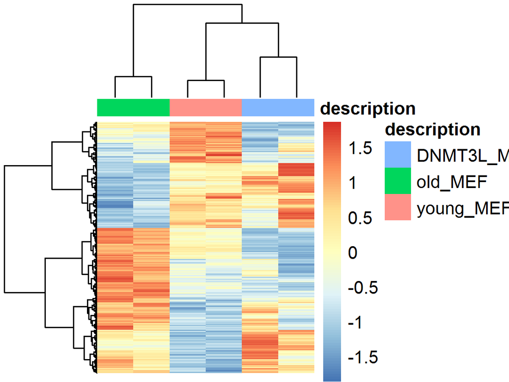

```r
anno_col <- sample_info %>%
  select(Sample, description) %>%
  tibble::column_to_rownames("Sample")

log10(data_filtered_matrix_expressed+1) %>%
  subset(rownames(.) %in% gene_descriptions$PROBE_ID) %>%
  pheatmap(scale="row", show_rownames=F, show_colnames=F, clustering_method = "ward.D2", annotation_col = anno_col)
```

## 0.7 Compare old vs treated

```r
hits <- topTable(limma_contrast, number = Inf, coef=1)

# hits <- limma_fit %>% eBayes() %>% topTable(coef = 2, number = Inf, p.value = fdr_limit )

gene_descriptions_old_treat <- inner_join(gene_info, hits %>%rownames_to_column("PROBE_ID")) %>%
  filter(adj.P.Val < fdr_limit) %>%
  # filter(P.Value < p_limit) %>%
  # filter(abs(logFC) > 1) %>%
  mutate(change = ifelse(logFC > 0, "Higher in old", "Lower in old"))
```

There are 3541 differentially expressed genes

```r
overlap_genes <- venn_with_pval(test = gene_descriptions$gene_name, reference = gene_descriptions_old_treat$gene_name, test_name = "youngVSold", reference_name = "treatVSold", return_overlap = T) %>% unique
```

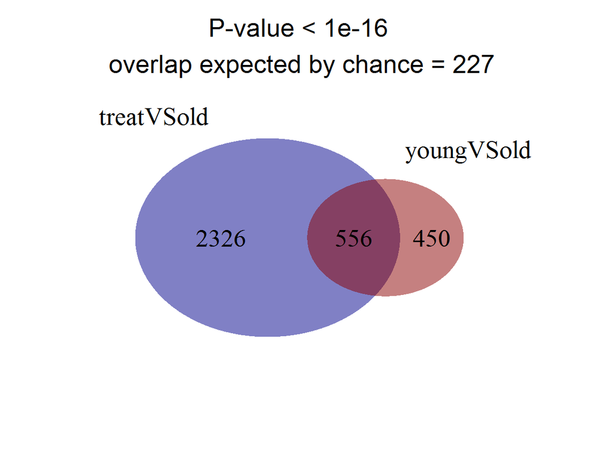

## 0.8 analyze genes thare are different in both comparisons

```r
tabled <- left_join(
  gene_descriptions %>% filter(gene_name %in% overlap_genes) %>%
  select(gene_name, youngVSold = change),
  gene_descriptions_old_treat %>% filter(gene_name %in% overlap_genes) %>%
  select(gene_name, treatVSold = change)
) %>% unique()
```

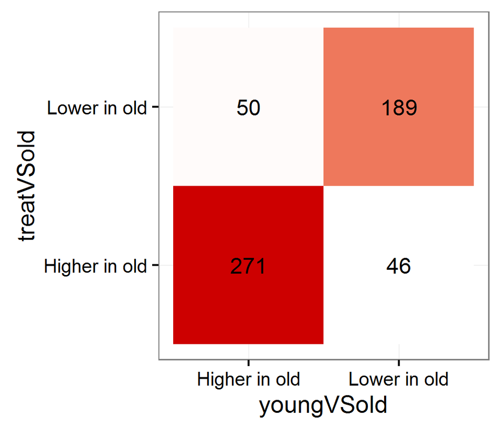

```r
tabled %>% group_by(youngVSold, treatVSold) %>% tally %>%
  ggplot(aes(youngVSold, treatVSold, label = n)) +
  geom_tile(aes(fill = n)) +
  geom_text() +
  scale_fill_continuous(low = "white", high = "red3") +
  theme_bw() +
  guides(fill=FALSE)
```

```r
concordant_direction <- tabled %>%
  filter(youngVSold == treatVSold)
```

82.7% of hits are concordant

- check some individual genes

```r
gene_set_query <- concordant_direction

final_matrix_long <- data_filtered_matrix %>% as.data.frame %>%
  rownames_to_column("PROBE_ID") %>%
  gather(key = "Sample", value = expr, -PROBE_ID) %>%
  left_join(., gene_info) %>%
  left_join(., sample_info) %>%
  mutate(description = factor(description, levels = unique(description %>% sort) %>% rev))
```

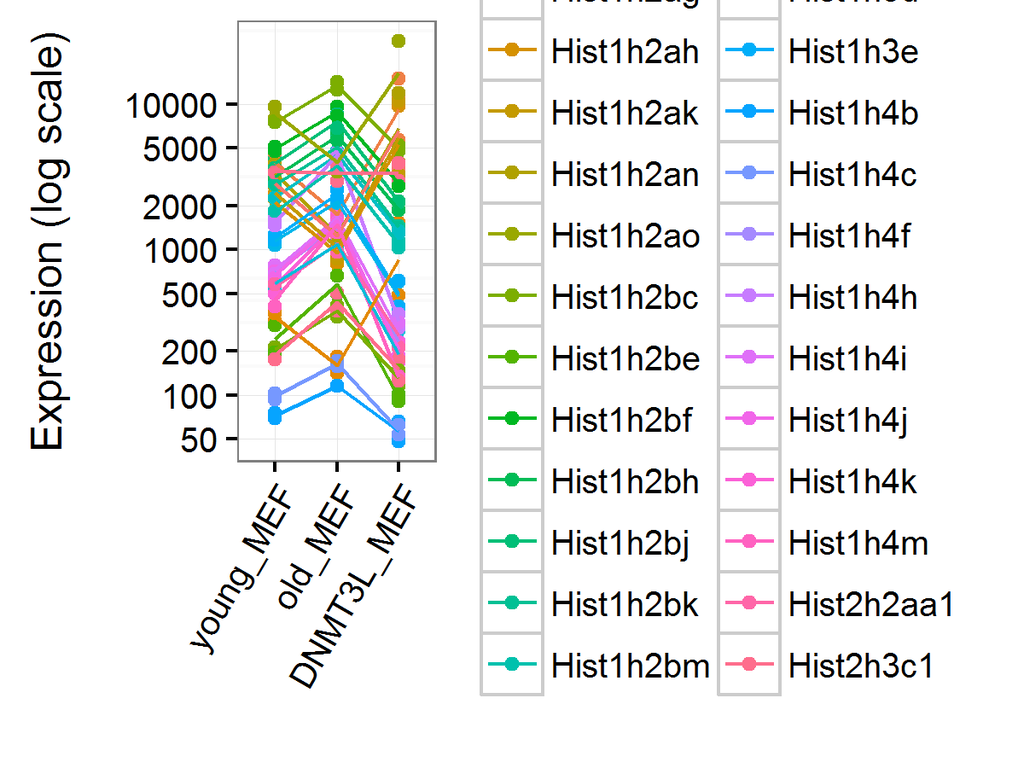

```r
check_gene(gene = grep("Hist", gene_set_query$gene_name, value = T), diff =T)
```

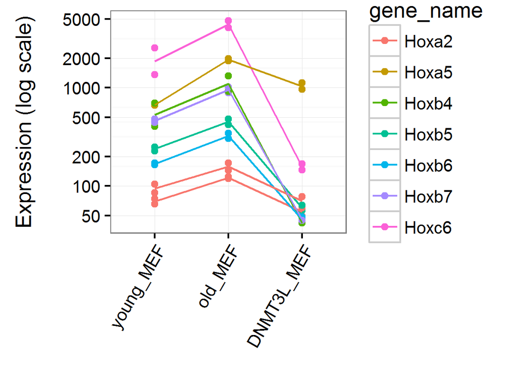

```r
check_gene(gene = grep("Hox", gene_info$gene_name, value = T), diff = T)
```

```r
# write.table(gene_info$refseq, "gene_set_background.txt", col.names = F, row.names = F, quote = F)
#
# gene_set_query %>%
#   filter(treatVSold == "Higher in old") %>%
#   select(gene_name) %>%
#   write.table("gene_set_foreground_upinold.txt", col.names = F, row.names = F, quote = F)
#
# gene_set_query %>%
#   filter(treatVSold != "Higher in old") %>%
#   select(gene_name) %>%
#   write.table("gene_set_foreground_downinold.txt", col.names = F, row.names = F, quote = F)
```

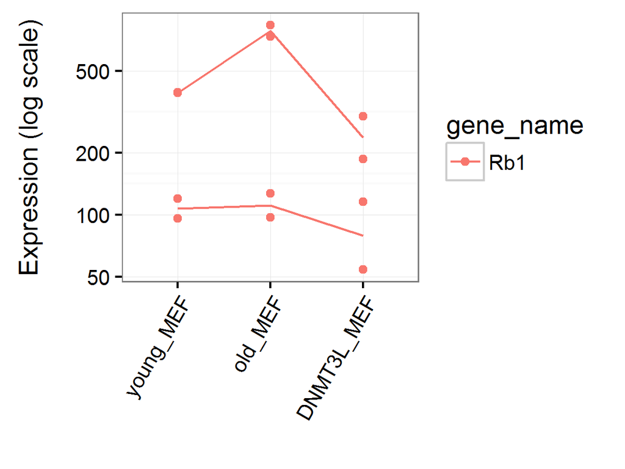

```r
check_gene("Rb1")
```

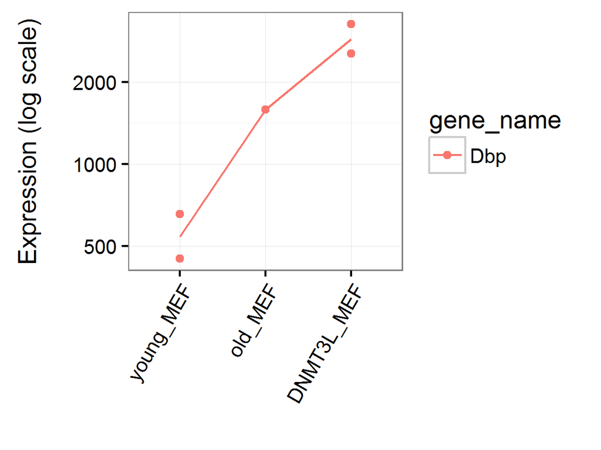

```r
check_gene("Dbp", diff = F)
```

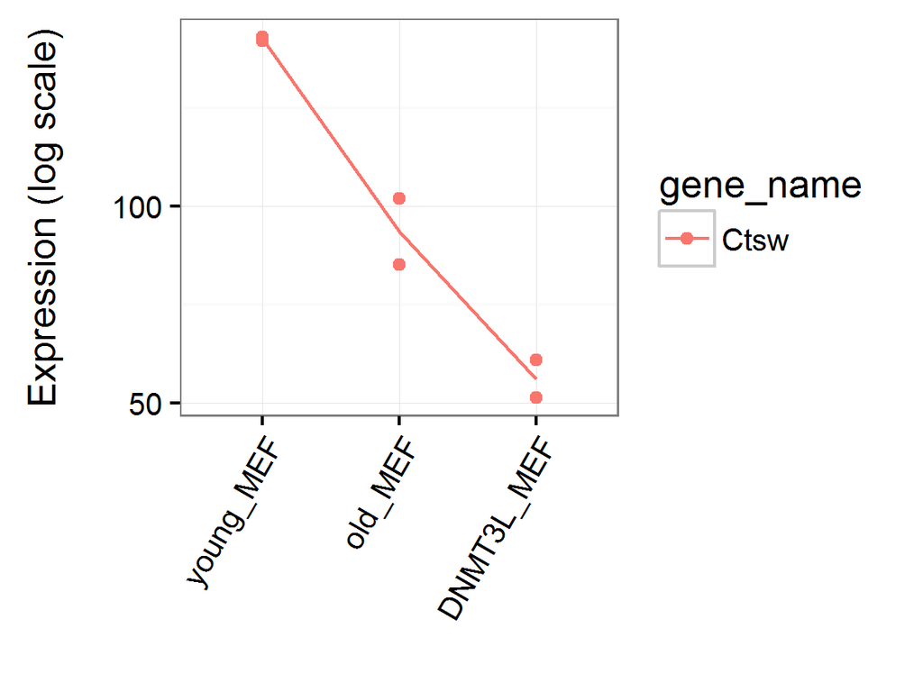

```r
check_gene("Ctsw", diff = F)
```

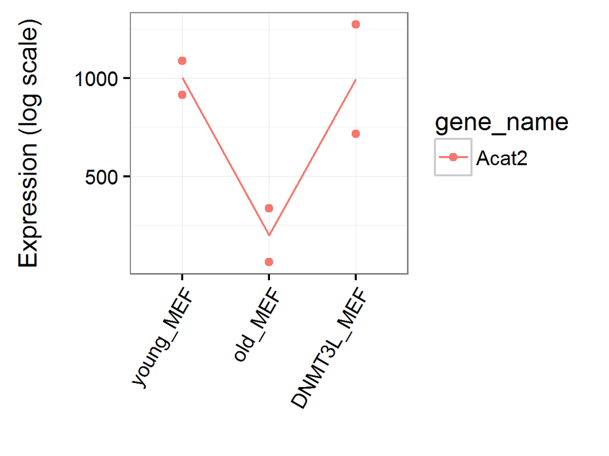

```r
check_gene("Acat2")
```

## 0.9 Overlap with other DNMT3L gene setes

### 0.9.1 DNMT3L knockdown in mESCs

Data from http://www.ncbi.nlm.nih.gov/geo/query/acc.cgi?acc=GSE44643

- differentially expressed

```r
gset <- read.delim("GSE44643_non_normalized.txt") %>%
  column_to_rownames("ID_REF")

# mart_data_2 <- getBM(attributes=c("external_gene_name", "illumina_mousewg_6_v2"), filters = "illumina_mousewg_6_v2", values = rownames(gExprs), mart=mart) %>% group_by(illumina_mousewg_6_v2) %>% do(head(., 1))
# saveRDS(mart_data_2, "mart_data_2.rds")

mart_data_2 <- readRDS("mart_data_2.rds") %>% filter(external_gene_name %in% gene_info$gene_name)

expressed <- gset %>% select(contains("p.value")) %>% .[rowSums(. < 0.05) >= 2,] %>% subset(rownames(.) %in% mart_data_2$illumina_mousewg_6_v2) %>% rownames(.)

gExprs <- gset %>% subset(rownames(.) %in% expressed) %>% select(-contains("p.value")) %>% normalizeQuantiles()

pdat <- data.frame(
  sample = colnames(gExprs)
) %>% mutate(group = gsub("([1-3])*\\.[1-2]", "", sample))
```

```r
limma_fit <- lmFit(log2(gExprs), design = model.matrix(~pdat$group)) %>% eBayes()

hits <- topTable(limma_fit, number = Inf, p.value = 0.01, coef = 2) %>%
  rownames_to_column("illumina_mousewg_6_v2")

dnmt3l_de_genes <- hits %>%
  left_join(mart_data_2, by = c("illumina_mousewg_6_v2"))
```

```r
venn_with_pval(
  # unique(gene_set_query$gene_name),
  gene_descriptions_old_treat$gene_name,
  dnmt3l_de_genes$external_gene_name,
  "dnmt3lVSold",
  "dnmt3l_kd"
)
```

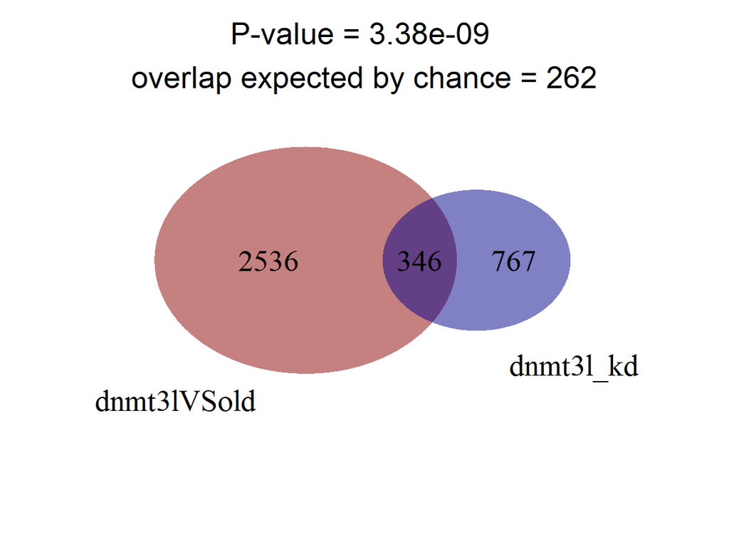

### 0.9.2 DNMT3L knockout MEFs

- from GSE69007

```r
# download.file("ftp://ftp.ncbi.nlm.nih.gov/geo/series/GSE69nnn/GSE69007/suppl/GSE69007_DESeq_mouseRNA_fpkm.NCBI_refseq.txt.gz", "dnmt3l_KO_expression.txt.gz")

d3l_ko_mef <- read.table("dnmt3l_KO_expression.txt.gz", header=T, sep = "\t")

# refseq_to_genename <- read.table("refseq_to_genename.txt", stringsAsFactors = F)
```

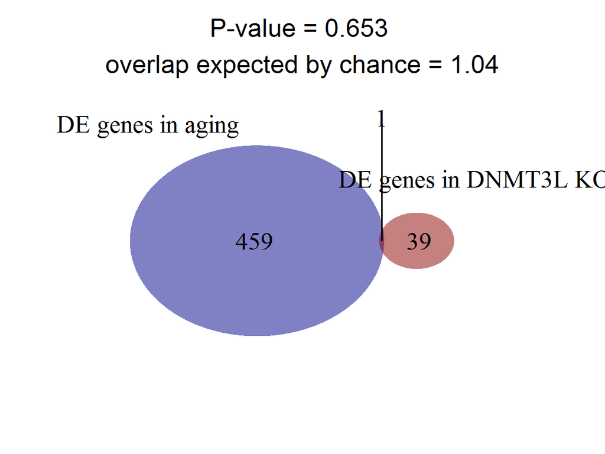

```r
d3l_ko_mef_genes <- d3l_ko_mef %>%
  select(refseq_mrna = fpkm.ID, fpkm.pvalue, fpkm.log2FoldChange) %>%
  filter(grepl("NM", refseq_mrna)) %>%
  mutate(refseq_mrna = gsub("\\..*", "", refseq_mrna)) %>%
  left_join(refseq_to_genename, by = c("refseq_mrna" = "V1")) %>%
  # unique() %>%
  filter(V2 %in% gene_info$gene_name) %>%
  filter(!is.na(fpkm.pvalue)) %>%
  mutate(fdr = p.adjust(fpkm.pvalue, "fdr")) %>%
  filter(fdr < fdr_limit) %>%
  .$V2 %>% unique

# rm(d3l_ko_mef)

venn_with_pval(test = d3l_ko_mef_genes, reference = gene_set_query$gene_name, test_name = "DE genes in DNMT3L KO", reference_name = "DE genes in aging")
```

## 0.10 Visualize Pathways

- Load pathways

```r
msigdb <- readLines("ReactomePathways.gmt") %>% str_split("\n")

msigdb <- lapply(msigdb, function(x) str_split(x, "\t") %>% unlist)

msigdb_names <- lapply(msigdb, function(x) x[1]) %>% unlist

# msigdb_species <- lapply(msigdb, function(x) x[2]) %>% unlist

# background <- background  %>% subset(!grepl("HIST", .))

msigdb_pruned <- lapply(msigdb, function(x) subset(x, x %in% background))

names(msigdb_pruned) <- msigdb_names

# msigdb_pruned <- msigdb_pruned[lapply(msigdb_pruned, length) >= 5]

# msigdb_pruned <- msigdb_pruned[!grepl("GSE|CANCER|_UP|_DN", names(msigdb_pruned))]

rm(msigdb)
```

- set up hypergeometric test
- test the gene sets

```r
higher_in_old <- gene_set_query  %>%
  filter(youngVSold == "Higher in old") %>%
  .$gene_name %>% unique

higher_in_old_pathways <- higher_in_old %>%
  master_test()

higher_in_young <- gene_set_query  %>%
  filter(youngVSold != "Higher in old") %>%
  .$gene_name %>% unique

higher_in_young_pathways <- higher_in_young %>%
  master_test()
```

Genes expressed in…

### 0.10.1 Higher in old

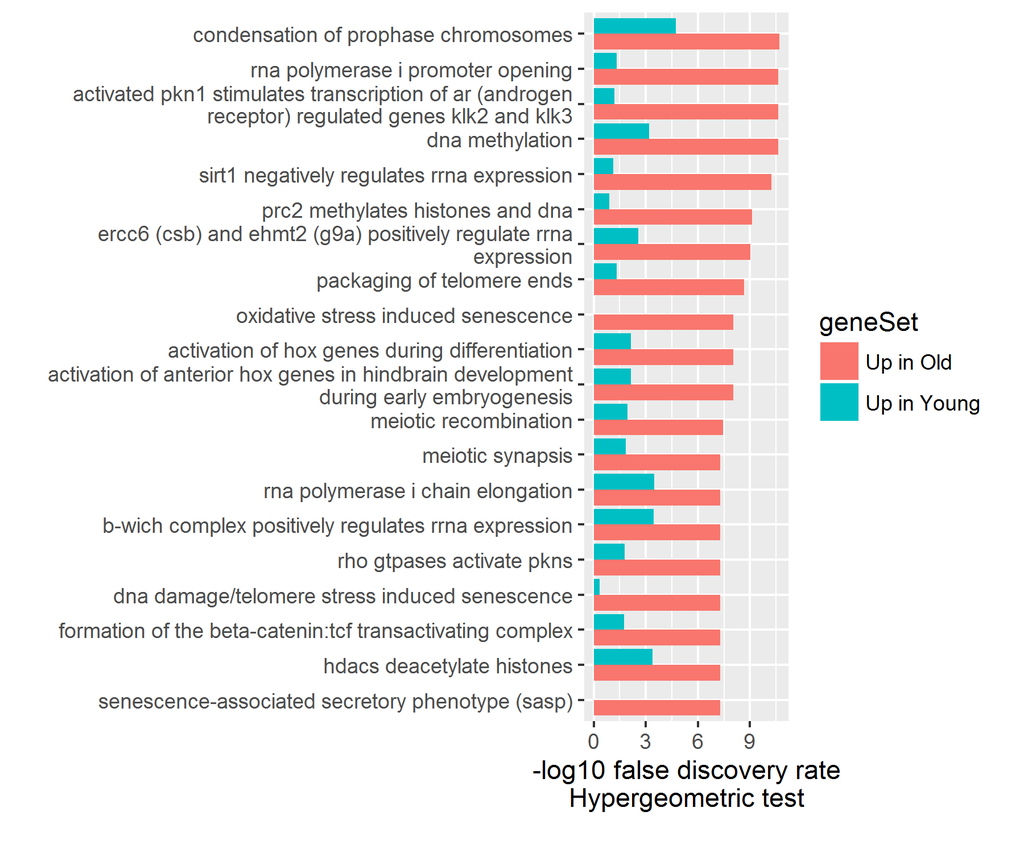

```r
plot_enriched_pathways(pathway_df = higher_in_old_pathways)
```

*trim 28

### 0.10.2 Higher in young

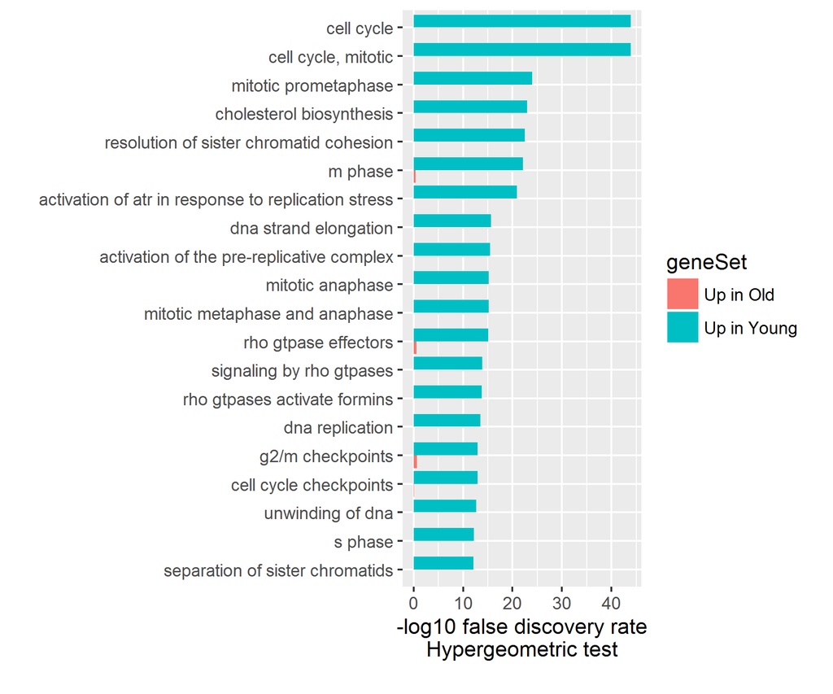

```r
plot_enriched_pathways(pathway_df = higher_in_young_pathways)
```

```r
check_pathway <- function(gene_set_name, db = msigdb_pruned, filter_hist = TRUE) {
  gene_set <- db[[gene_set_name]]
  higherInOld <- higher_in_old %>% toupper %>% .[. %in% gene_set]
  higherInYoung <- higher_in_young %>% toupper %>% .[. %in% gene_set]
  if (filter_hist) {
    higherInOld <- higherInOld %>% .[!grepl("HIST", .)]
    higherInYoung <- higherInYoung %>% .[!grepl("HIST", .)]
  }
  y <- list(gene_set_name = gene_set_name, higherInOld = higherInOld, higherInYoung = higherInYoung, all= gene_set)
  names(y)[4] <- gene_set_name
  return(y)
}

check_pathway(higher_in_old_pathways$gene_set[1])[1:3]
```

http://www.mousephenotype.org/data/genes/MGI:87871#section-associations http://amp.pharm.mssm.edu/Enrichr/enrich http://journals.plos.org/plosone/article?id=10.1371/journal.pone.0057172

### 0.10.3 Higher in old (DNMT3L vs old)

- Also try for all DNMT3L vs old differentially expressed genes to see what other pathways may come up - broad pathways affected by DNMT3L

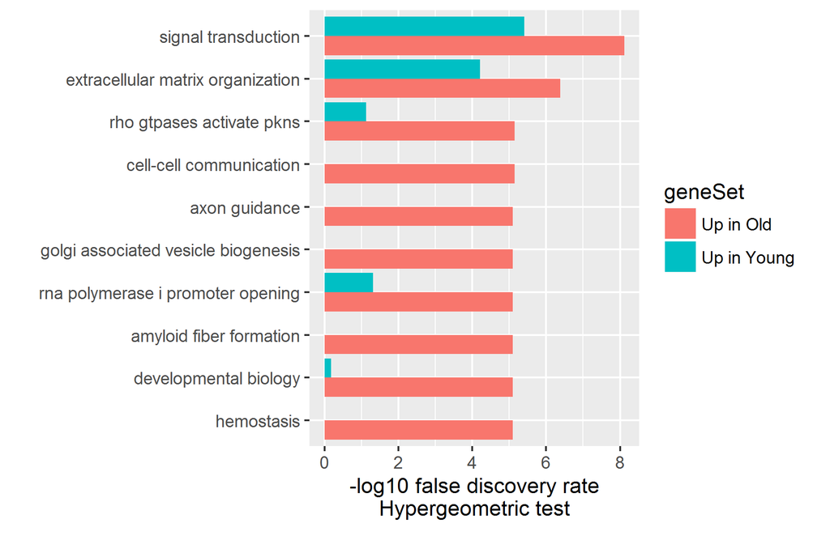

```r
treated_vs_old <- list()
treated_vs_old[[1]] <- gene_descriptions_old_treat %>% filter(logFC > 0, adj.P.Val<0.05) %>% .$gene_name
treated_vs_old[[2]] <- gene_descriptions_old_treat %>% filter(logFC < 0, adj.P.Val<0.05) %>% .$gene_name

treated_vs_old_results <- lapply(list(higher_in_old = treated_vs_old[[1]], higher_in_young = treated_vs_old[[2]]), FUN = master_test, db = msigdb_pruned)

plot_enriched_pathways(pathway_df = treated_vs_old_results[[1]], n_terms = 10, old_df = treated_vs_old_results[[1]], young_df = treated_vs_old_results[[2]])
```

### 0.10.4 Higher in young (DNMT3L vs old)

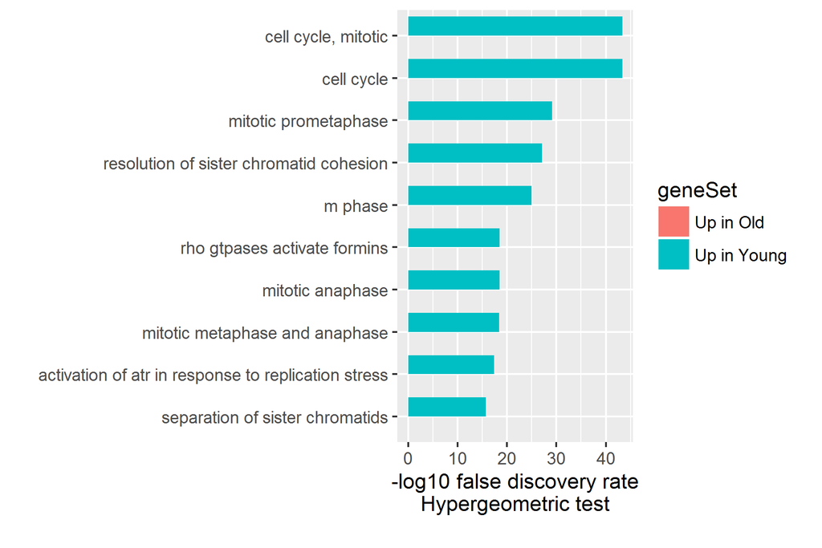

```r
plot_enriched_pathways(pathway_df = treated_vs_old_results[[2]], n_terms = 10, old_df = treated_vs_old_results[[1]], young_df = treated_vs_old_results[[2]])
```

## 0.11 ChEA enrichment

Transcription factor regulated genes, as determined by ChIP-seq or ChIP-ChIP

Data downloaded from http://amp.pharm.mssm.edu/Enrichr/#stats

```r
db <- readLines("ChEA_2015.txt") %>% str_split("\n") %>% lapply(function(x) str_split(x, "\t") %>% unlist %>% gsub("\\,1\\.0", "", .))

cheaDB_names <- lapply(db, function(x) x[1]) %>% unlist

db <- lapply(db, function(x) subset(x, x %in% background))

universe <- background %>% length()

names(db) <- cheaDB_names

cheaDB <- db %>% .[grepl("Mouse", names(.))]
```

```r
chea_TF_results <- lapply(list(higher_in_old = higher_in_old, higher_in_young = higher_in_young), FUN = master_test, db = cheaDB)
```

### 0.11.1 Old

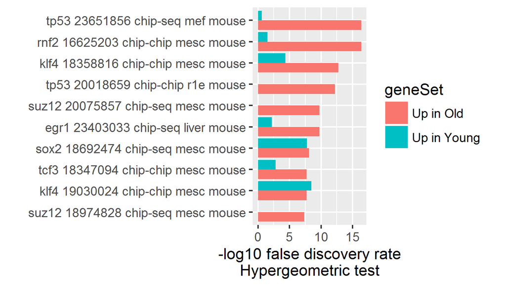

```r
plot_enriched_pathways(pathway_df = chea_TF_results[[1]], n_terms = 10, old_df = chea_TF_results[[1]], young_df = chea_TF_results[[2]])
```

### 0.11.2 young

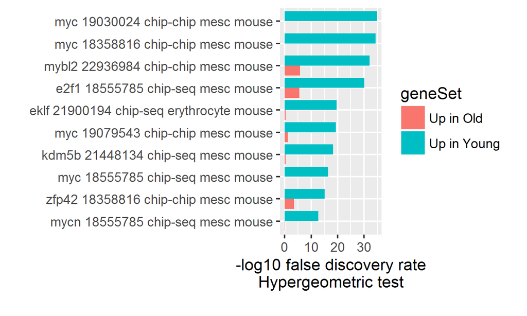

```r
plot_enriched_pathways(pathway_df = chea_TF_results[[2]], n_terms = 10, old_df = chea_TF_results[[1]], young_df = chea_TF_results[[2]])
```

```r
check_pathway(gene_set_name = grep("KLF4_19", names(cheaDB), value = T)[1], db = cheaDB)[1:3]
```

## 0.12 Encode histone enrichment

Data downloaded from http://amp.pharm.mssm.edu/Enrichr/#stats

```r
db <- readLines("ENCODE_Histone_Modifications_2015.txt") %>% str_split("\n") %>% lapply(function(x) str_split(x, "\t") %>% unlist)

names <- lapply(db, function(x) x[1]) %>% unlist

db <- lapply(db, function(x) subset(x, x %in% background))

names(db) <- names

encode <- db %>% .[grepl("_mm9", names(.))]
```

### 0.12.1 Old

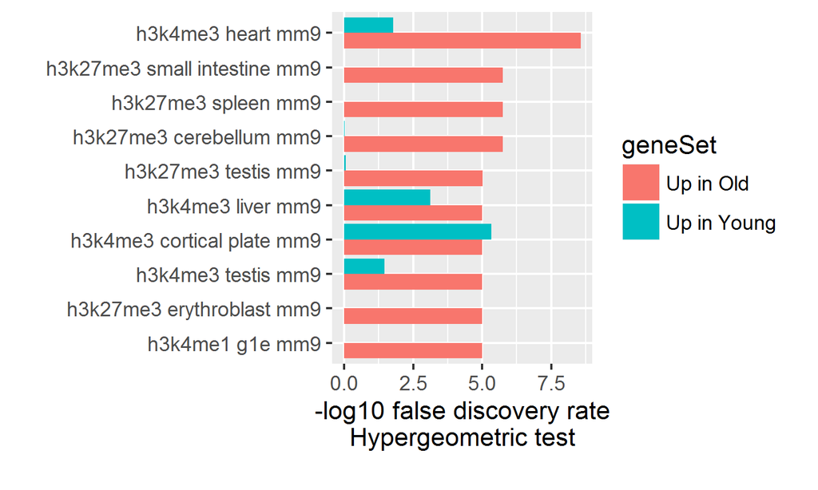

```r
encode_histones <- lapply(list(higher_in_old = higher_in_old, higher_in_young = higher_in_young), FUN = master_test, db = encode)

plot_enriched_pathways(pathway_df = encode_histones[[1]], n_terms = 10, old_df = encode_histones[[1]], young_df = encode_histones[[2]])
```

### 0.12.2 young

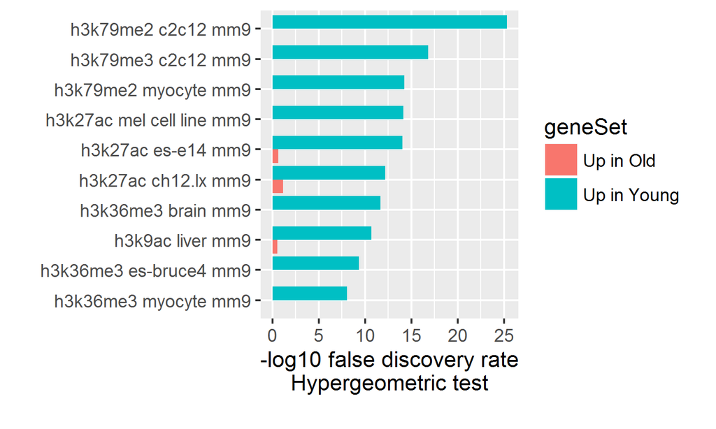

```r
plot_enriched_pathways(pathway_df = encode_histones[[2]], n_terms = 10, old_df = encode_histones[[1]], young_df = encode_histones[[2]])
```

## 0.13 Homer results

### 0.13.1 old

[interactive chart not shown]

### 0.13.2 young

[interactive chart not shown]

## 0.14 Model

### 0.14.1 Overview

Sensense is regulated by rnf2, a critical component of PRC1. In old mice, senescent genes normally silenced by PRC1 are reactivated, and cause the cell to sensence. Indeed, these genes are typically associated with repressive marks across a wide variet of ENCODE cell lines.

However, pulse of DNMT3L causes these senescence genes to be re-silenced, and allows to cells to exit senenscence. Interestingly, this silencing is stable even in the abscence of DNMT3L.

### 0.14.2 Previous literature

- Cdkn2a

Interestingly, PK^INK4a (Cdkn2a) is previously implicated as a [master regulator of senescence](http://www.nature.com/nature/journal/v506/n7488/full/nature13013.html) (ref 19-22 within). In our data, it appears DNMT3L does not silence this gene, even though PRC1 is supposed to supress it (ref 26-28 within).

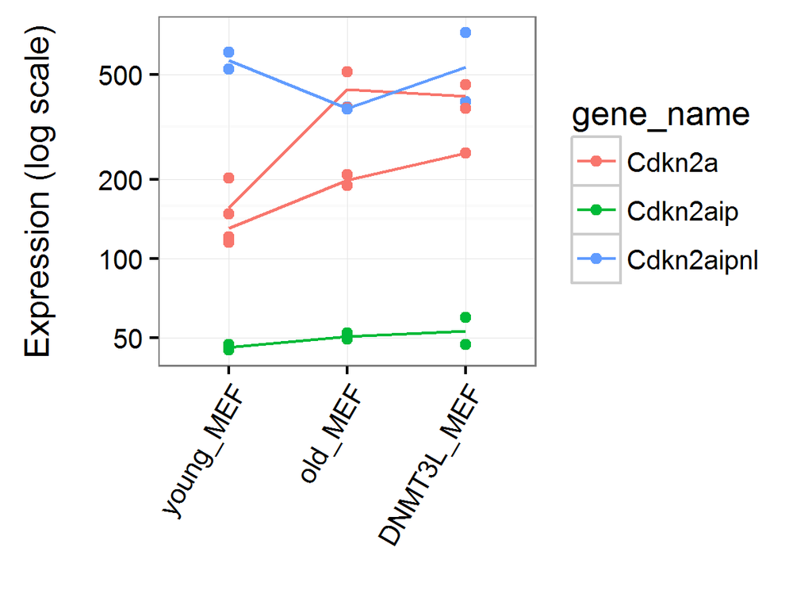

```r
check_gene(gene = grep("Cdkn2a", gene_info$gene_name, value = T), diff = F)
```

- Rb1 and p53

Supposedly, *Rb1* and *p53* are the two “master regulators” of senescence, as stated in [this review](http://www.nature.com/onc/journal/v30/n26/full/onc201134a.html)

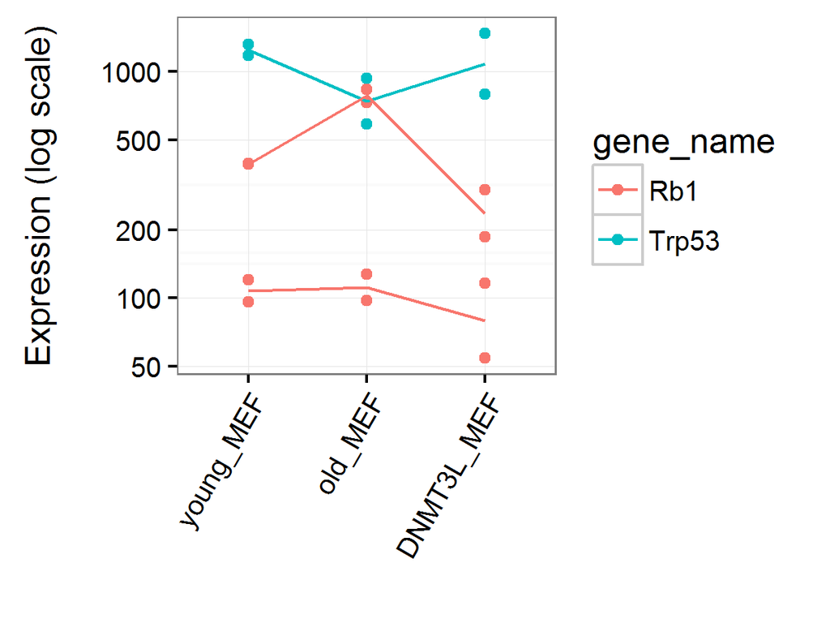

```r
check_gene(gene = grep("Rb1$|Trp53$", gene_info$gene_name, value = T), diff = F)
```

Interesting, neither gene seem involved in the senescnece observed here. p53’s notable target genes, Bax, Apaf, Mdm2, and p21 (aka Cdkn1a), seem to be changed in DNMT3L pulse, but not during young MEF

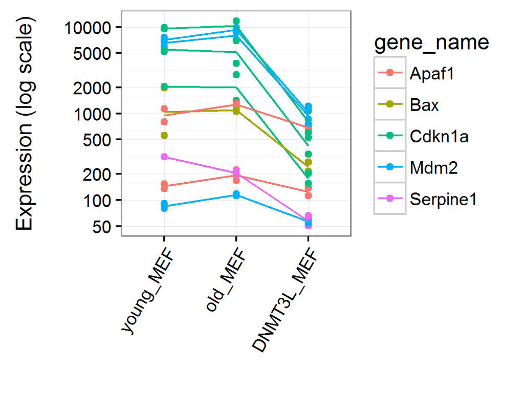

```r
check_gene(gene = grep("Bax|Apaf|Mdm2|Cdkn1a|Serpine1", gene_info$gene_name, value = T), diff = F)
```

Rb1 seems to supress E2F target genes via Cdkn2a [ref](http://www.sciencedirect.com/science/article/pii/S009286740300401X). Since Cdkn2a doesn’t seem to be changed during DNMT3L induction, Rb1 is probably not involved. Interesting, because Cdkn2a is a PRC1 target [ref](http://www.nature.com/onc/journal/v30/n26/full/onc201134a.html#Transcriptional-regulation-of-the-INK4A-ARF-locus), and I think PRC1 is involved… for some reason Cdkn2a escapes

- PRC1 is important for senescence

Becuase our study identified Rnf2 as a core regulator of our differentially expressed genes, and Rnf2 is a core member of PRC1 [genecards.com](http://www.genecards.org/cgi-bin/carddisp.pl?gene=RNF2)

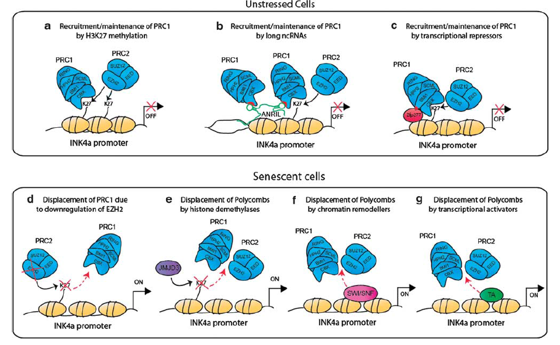

Bmi1 defecient MEFs senescence early by allowing Cdkn2a to activate [ref](http://www.nature.com/nature/journal/v397/n6715/full/397164a0.html). In our case, it seems expression of **Bmi1** increases upon DNMT3L induction. In addition, Cbx7, and Mel18 (Pcgf2) knockdown leads to cellular arrest, the same as Bmi1. But the data doesn’t show difference in expression, except maybe Cbx7 being upregulated.

Zfp277 is required for Bmi1 mediated senescence, such that Zfp277 knockout can’t be rescued with Bmi1

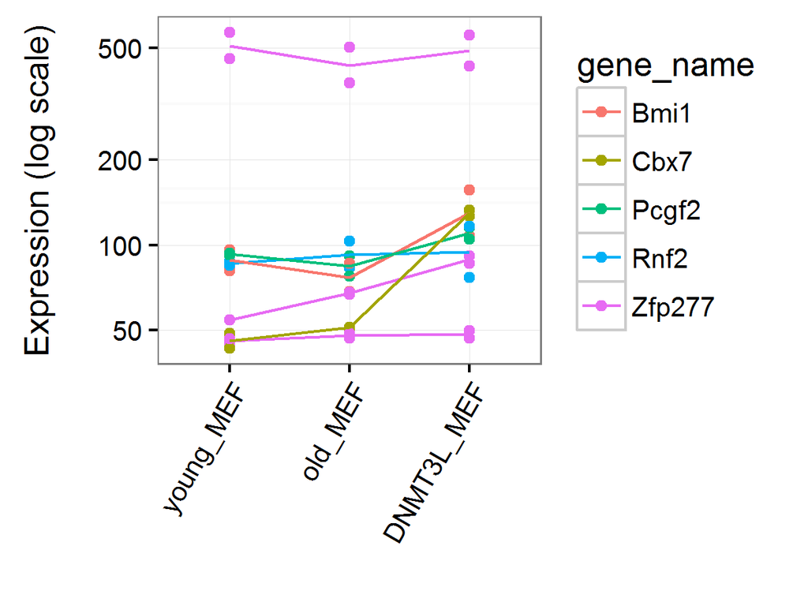

```r
check_gene(gene = grep("Rnf2$|Bmi|Cbx7|Pcgf2|Zfp277", gene_info$gene_name, value = T), diff = F)
```

Good [paper](http://journals.plos.org/plosgenetics/article?id=10.1371/journal.pgen.1000506) about PRC1 and PRC2 (introduction section)

- How does DNMT3L recruit PRC to senescence related genes?

Turns out H3K27me3 is required for PRC1 recruitment to this loci, and Ezh2/Suz12/Eed is responsible since PRC1 is recruited to sites of H3K27me3. Expression of Ezh2 is increased, but not statistically significant.

JMJD3 (aka Kdm6b) removes H3K27me3 and allows senescence to happen [ref](http://genesdev.cshlp.org/content/23/10/1177.full).

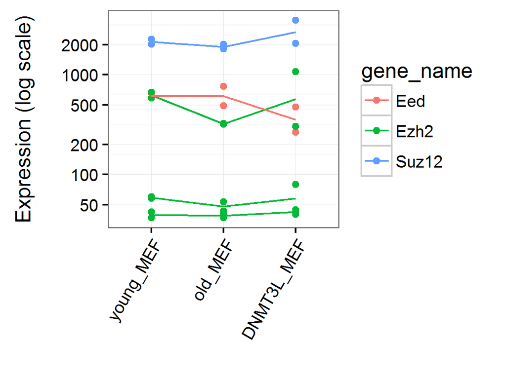

```r
check_gene(gene = grep("Ezh2|Suz12|Eed", gene_info$gene_name, value = T), diff = F)
```

DNMT3L binds directly to Ezh2 and Suz12. ref. Apparently, DNMT3L kicks out other DNMTs and prevents methylation of the loci. **should bisulfite sequence this to check**. The paper also performed DNMT3L Chip-seq, so it should be possible to check.

As for HOX genes, looks like HOTAIR recruits PRC2 to the hox cluster [ref](http://www.ncbi.nlm.nih.gov/pubmed/17604720). Furthermore, knocking out DNMT3L’s binding domain causes HOX genes to increase expression (in spermatogonia) [ref](http://dx.doi.org/10.1016/j.celrep.2015.01.021). This explains why Hox is higher expressed in old, because it’s losing PRC2 repression.

Actually, looks like others cannot replicate the interaction between DNMT3L and EZH2 [ref](http://dx.doi.org/10.1016/j.celrep.2015.01.021). Yes interaction in ESC, no interaction in sperm.

A good review to study how PRC complexes are recruited to genomeic regions [ref](http://www.nature.com/nrm/journal/v16/n11/full/nrm4067.html).

Should take a look at PRC1 (rnf2) and PRC2 (suz12) binding regions [ref](http://www.nature.com/nature/journal/v441/n7091/suppinfo/nature04733.html)) and DNMT3L binding regions [ref](http://www.ncbi.nlm.nih.gov/pubmed/24074865). To look for overlap.

- Interaction with H3K9me3

DNMT3L is known to interact with K9me3 *ref needed* via setDB1. PRC2 complex members weakly interacts with setDB1, but strongly with G9a (which does the same thing as setDB1) [ref](http://doi:10.1016/j.molcel.2013.12.005).

## 0.15 Analyze overlap between H3K27me3 and DNMT3L binding

### 0.15.1 Data description

- mESC data
  - mESC **DNMT3L** data from http://www.ncbi.nlm.nih.gov/geo/query/acc.cgi?acc=GSE49178 (http://www.cell.com/cell/fulltext/S0092-8674(13)01087-8)
  - **DNMT3a and DNMT3b** chip-seq and **DNA-methylation** from http://www.ncbi.nlm.nih.gov/geo/query/acc.cgi?acc=GSE57412
  - mESC **H3K27me3** **Ring-1b**, and **Suz12** data from http://www.ncbi.nlm.nih.gov/geo/query/acc.cgi?acc=GSE72164 (paper from http://www.sciencedirect.com/science/article/pii/S1934590915005081)
  - mESC **K4me3** from http://www.ncbi.nlm.nih.gov/geo/query/acc.cgi?acc=GSM1499136
  - **Fbxl10** chip-seq - http://www.ncbi.nlm.nih.gov/geo/query/acc.cgi?acc=GSM930141, from http://www.nature.com/ng/journal/v47/n5/full/ng.3272.html#ref6
  - **SetDB1 and H3K9me3** chip-seq (mm8) (supplmental 6 and 7) - http://genesdev.cshlp.org/content/23/21/2484/suppl/DC2
  - Bivalent **H3k4me3 and h3k27me3 co-chip** from http://www.ncbi.nlm.nih.gov/geo/query/acc.cgi?acc=GSE83833
  - All in E14 mES cells in DMEM, all aligned to mm9
- MEF data
  - MEF **H3k27me3** and **Suz12** data from http://www.ncbi.nlm.nih.gov/geo/query/acc.cgi?acc=GSE57926
  - MEF **K4Me3** from ENCODe - http://www.ncbi.nlm.nih.gov/geo/query/acc.cgi?acc=GSM1382353
  - MEF **Ring1b/Rnf2** from http://www.ncbi.nlm.nih.gov/geo/query/acc.cgi?acc=GSM1050218
  - **DNA methylation** from http://www.ncbi.nlm.nih.gov/geo/query/acc.cgi?acc=GSE44760
  - **5hmc** from http://www.ncbi.nlm.nih.gov/geo/query/acc.cgi?acc=GSM1087010
- Other data
  - Aging b-cells full epigenome from http://www.ncbi.nlm.nih.gov/geo/query/acc.cgi?acc=GSE68618
- Consider using https://www.bioconductor.org/packages/devel/bioc/vignettes/CoverageView/inst/doc/CoverageView.pdf to calculate data

```r
# Download ESC PRC1 and PRC2 data
download.file("ftp://ftp.ncbi.nlm.nih.gov/geo/samples/GSM1856nnn/GSM1856427/suppl/GSM1856427_H3K27me3_TC_std_c3_merged_8016.mem.sorted.q60.rmdup.count.bedGraph.gz", "dnmt_chipseq/h3k27me3_rep1.bedGraph.gz")

download.file("ftp://ftp.ncbi.nlm.nih.gov/geo/samples/GSM1856nnn/GSM1856428/suppl/GSM1856428_H3K27me3_TC_std_c3_merged_8022.mem.sorted.q60.rmdup.count.bedGraph.gz", "dnmt_chipseq/h3k27me3_rep2.bedGraph.gz")

download.file("ftp://ftp.ncbi.nlm.nih.gov/geo/samples/GSM1856nnn/GSM1856437/suppl/GSM1856437_Ring1B_broad_merged_serum_8188.mem.sorted.q60.rmdup.count.bedGraph.gz", "dnmt_chipseq/ring1b_rep1.bedGraph.gz")

download.file("ftp://ftp.ncbi.nlm.nih.gov/geo/samples/GSM1856nnn/GSM1856438/suppl/GSM1856438_Ring1B_broad_merged_serum_8469.mem.sorted.q60.rmdup.count.bedGraph.gz", "dnmt_chipseq/ring1b_rep2.bedGraph.gz")

download.file("ftp://ftp.ncbi.nlm.nih.gov/geo/samples/GSM1856nnn/GSM1856444/suppl/GSM1856444_Suz12_broad_merged_serum_8185.mem.sorted.q60.rmdup.count.bedGraph.gz", "dnmt_chipseq/suz12_rep1.bedGraph.gz")

download.file("ftp://ftp.ncbi.nlm.nih.gov/geo/samples/GSM1856nnn/GSM1856445/suppl/GSM1856445_Suz12_broad_merged_serum_8465.mem.sorted.q60.rmdup.count.bedGraph.gz", "dnmt_chipseq/suz12_rep2.bedGraph.gz")

download.file("ftp://ftp.ncbi.nlm.nih.gov/geo/samples/GSM1856nnn/GSM1856445/suppl/GSM1856445_Suz12_broad_merged_serum_8465.mem.sorted.q60.rmdup.count.bedGraph.gz", "dnmt_chipseq/suz12_rep2.bedGraph.gz")

#download ESC dna methylation data

download.file("ftp://ftp.ncbi.nlm.nih.gov/geo/series/GSE30nnn/GSE30202/suppl/GSE30202_BisSeq_ES_CpGmeth.tsv.gz", "esc_cpg.tsv.gz")

# MEF DNA methylation

download.file("ftp://ftp.ncbi.nlm.nih.gov/geo/series/GSE44nnn/GSE44760/suppl/GSE44760_RRBS_Dnmt1WT_KO_CpGs.txt.gz", "mef_cpg.txt.gz")

# MEF 5hmc

download.file("ftp://ftp.ncbi.nlm.nih.gov/geo/samples/GSM1087nnn/GSM1087010/suppl/GSM1087010_5hmC_MEF.bed.gz", "mef_h5mc.bed.gz")
```

- find promoters that have binding peaks within

```r
refseq_genes <- read.table("refseq.bed.gz", stringsAsFactors = F) %>%
  setnames(c("refseq_id", "chr", "strand", "start", "end", "gene_name")) %>%
  filter(gene_name %in% gene_info$gene_name) %>%
  unique() %>%
  makeGRangesFromDataFrame(keep.extra.columns = T)

names <- dir("dnmt_chipseq/", "*", full.names = T) %>% grep(pattern = "*.gz", x = ., value = T) %>% subset(!grepl("ENCODE", .))

chipseq_bed <- lapply(names, function(x) {
  read.table(x, stringsAsFactors = F) %>% rename(chr = V1, start = V2, end = V3) %>% makeGRangesFromDataFrame(keep.extra.columns = T)
  })

names(chipseq_bed) <- names %>% basename() %>% gsub("\\..*", "", .) %>% gsub("GSM[1-9]*_(.*)", "\\1", .) %>% paste0("ESC_", .)
```

```r
# Also read CpG methylation
esc_meth <- data.table::fread("ESC_cpg.tsv", data.table = F) %>% filter(nTot >= 5, chr != "chrY") %>% mutate(meth = nMeth/nTot, end = position+2) %>% select(chr, start = position, end, meth) %>% makeGRangesFromDataFrame(keep.extra.columns = T)
```

```
##
Read 0.0% of 19079823 rows
Read 37.1% of 19079823 rows
Read 75.5% of 19079823 rows
Read 19079823 rows and 4 (of 4) columns from 0.355 GB file in 00:00:08
```

```r
refseq <- refseq_genes %>%
  promoters(upstream = 2000, downstream = 2000)

esc_meth_overlaps_table <- findOverlaps(esc_meth, refseq, type = "within")

esc_meth_overlaps <- cbind(
  queryHits(esc_meth_overlaps_table) %>% esc_meth[.,] %>% as.data.frame(),
  subjectHits(esc_meth_overlaps_table) %>% refseq[.,] %>% mcols()
) %>% as.data.frame() %>%
  group_by(gene_name) %>%
  summarize(meth = mean(meth), n_cpg = n()) %>%
  filter(n_cpg >= 5)

rm(esc_meth)
rm(esc_meth_overlaps_table)
gc()
```

```
##           used  (Mb) gc trigger  (Mb)  max used  (Mb)
## Ncells 2614535 139.7    3886542 207.6   3886542 207.6
## Vcells 8939277  68.3  101082723 771.2 126330559 963.9
```

```r
find_overlapping_promoters <- function(subject_peaks, query_promoters = refseq, minoverlap = 1) {
  suppressWarnings(subsetByOverlaps(subject = subject_peaks, query = query_promoters, minoverlap = minoverlap))
}

chipseq_bed_promoter_overlap <- lapply(chipseq_bed, function(x) find_overlapping_promoters(x) %>% .$gene_name %>% unique())
```